# Assignment 01: The Reproducibility Hello World

Author

Abbey Hightower

## Setup

Load the packages you need in this chunk. You need `tidyverse` and `here`. The penguin data comes from `palmerpenguins`.

```r
library(tidyverse)
library(here)

# Load the penguins data WITHOUT attaching the whole package:
data(penguins, package = "palmerpenguins")
```

## Data provenance

Write 2-3 sentences: what is this dataset, where does it come from, and why do we load it with `data()` instead of reading a CSV you placed by hand?

> *This data was downloaded as a library R package online that contains much more data than a regular CSV file. This data needed to be installed and loaded into the code. By using the ‘data()’ function the user only loads the necessary data for analysis and not the entire library package.*

## The plot

Build a scatterplot of **bill length** (x) vs **bill depth** (y), colored by **species**. Save the plot to the object named `penguin_plot` exactly as shown. The grader looks for that object name.

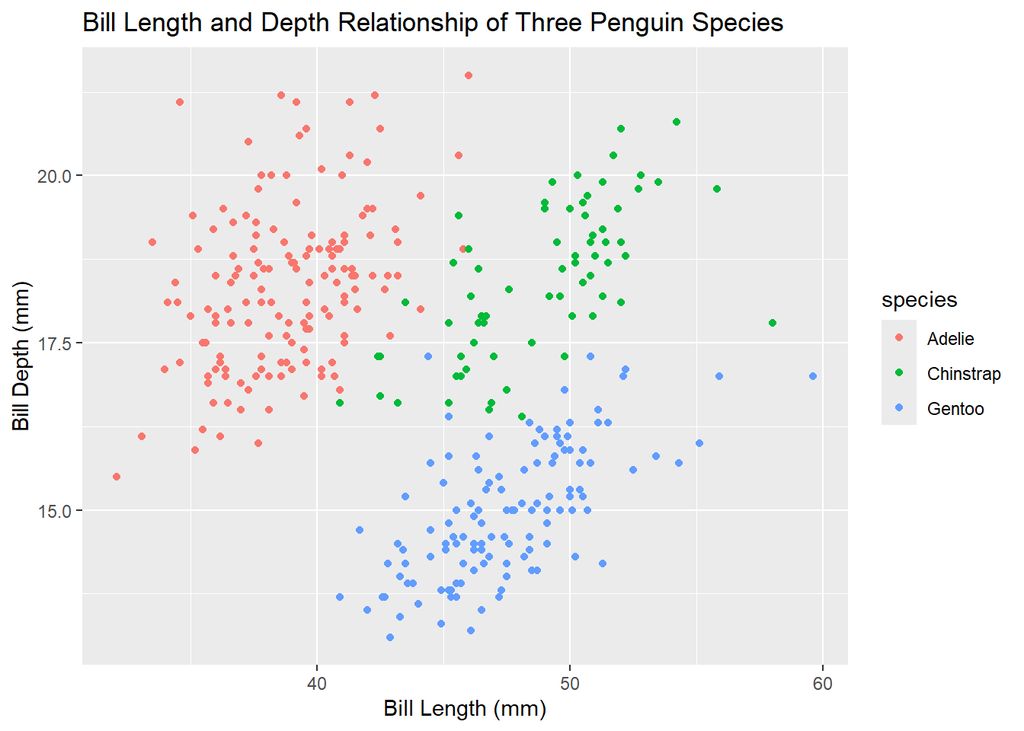

```r
penguin_plot <- penguins |>
  ggplot(aes(
    x = bill_length_mm,          # TODO: bill length column
    y = bill_depth_mm,          # TODO: bill depth column
    color = species      # TODO: map species INSIDE aes()
  )) +
  geom_point() +
  labs(
    title = "Bill Length and Depth Relationship of Three Penguin Species",    # TODO: a clear title
    x = "Bill Length (mm)",
    y = "Bill Depth (mm)"
  )

penguin_plot
```

## Methods note (AI use)

If you used AI to troubleshoot, say what you asked and what you learned. If not, write “No AI used.”

> *No AI used*